# Moving Average Models

As an alternative to the autoregressive representation in which the $X_t$ on the left-hand side of the equation are assumed to be combined linearly, the moving average model of order $q$, abbreviated as $MA(q)$, assumes the white noise $W_t$ on the right-hand side of the defining equation are combined linearly to form the observed data.

The **moving average model** of order $q$, or $MA(q)$ model, is defined to be

$$ X_t = W_t + \theta_1 W_{t-1} + \theta_2 W_{t-2} + \cdots + \theta_q W_{t-q} $$

where $W_t \sim \mathcal{N}(0, \sigma^2_W)$, and $\theta_1, \cdots, \theta_q$ are parameters with $\theta_q \neq 0$.

$$ X_t = \theta(B)W_t = (1 + \theta_1 B + \theta_2 B^2 + \cdots + \theta_q B^q)W_t $$

where

$$ \theta(B) = 1 + \theta_1 B + \theta_2 B^2 + \cdots + \theta_q B^q $$

defines the **moving average operator**.

## The $MA(1)$ Model

Consider the $MA(1)$ model, given by $X_t = W_t + \theta W_{t-1}$. Then

$$ \mathbb{E}[X_t] = 0 $$

and,

$$ \gamma(h) = \begin{cases} (1 + \theta^2) \sigma^2_W & h=0 \\ \theta \sigma^2_W & h=1 \\ 0 & h > 1 \end{cases} $$

which is stationary.

### Example of an $MA(1)$ Process

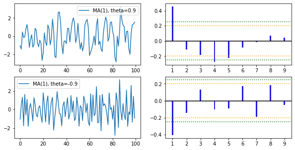

```python
figure
```

## Non-uniqueness of MA Models and Invertibility

The ACF of the $MA(1)$ process given by $X_t = W_t + \theta W_{t-1}$ is

$$ \rho(h) = \begin{cases} \frac{\theta}{1 + \theta^2} & h=1 \\ 0 & h > 1 \end{cases} $$

We notice that $\rho(h)$ is the same for $\theta$ and $\frac{1}{\theta}$. Then, consider the process

$$ Y_t = V_{t} + \theta^{-1} V_{t-1} $$

where $V_t \sim_{i.i.d.} \mathcal{N}(0, \theta^2 \sigma^2_W)$ Then both processes $X_t$ and $Y_t$ are statistically equal, yielding the same autocovariance function.

### Example of Non-uniqueness of MA Models

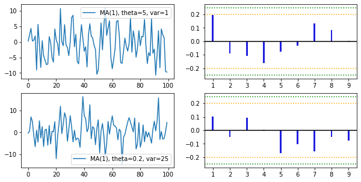

```python
figure
```

For convenience, by mimicking the criterion of causality for $AR$ models, we will choose the model with an infinite AR representation. Such a process is called an invertible process.

As in the $AR$ case, the $MA$ has the polynomial, $\theta(z)$, corresponding to the moving average operators $\theta(B)$, where $\theta(B)$ is

$$ \theta(B) = 1 + \theta_1 B + \theta_2 B^2 + \cdots + \theta_q B^q $$

and $\theta(z)$ is

$$ \theta(z) = 1 + \theta_1 z + \theta_2 z^2 + \cdots + \theta_q z^q $$